# Hooper_ESM211_HW3

Tess Hooper

2/18/2020

### 1. Make a matrix for Loggerhead Turtle population

**1.1. Make and print matrix**

```r
class_names <- c("Egg", "Sm Juv", "Lg Juv", "Subadult", "Adult")
A <- matrix(c(0, 0, 0, 4.665, 61.896,
               0.675, 0.703, 0, 0, 0,
               0, 0.047, 0.657, 0, 0,
               0, 0, 0.019, 0.682, 0,
              0, 0, 0, 0.061, 0.809),
nrow = 5, ncol = 5, byrow = TRUE, dimnames = list(class_names, class_names))

# Eggs per subadult and eggs per adult

print(A)
```

```
##            Egg Sm Juv Lg Juv Subadult  Adult
## Egg      0.000  0.000  0.000    4.665 61.896
## Sm Juv   0.675  0.703  0.000    0.000  0.000
## Lg Juv   0.000  0.047  0.657    0.000  0.000
## Subadult 0.000  0.000  0.019    0.682  0.000
## Adult    0.000  0.000  0.000    0.061  0.809
```

**1.2. Print out subets of A.**

```r
## Matrix are first presented by ROW then COLUMN


# Print subset for row 4, column 3
print(A[4, 3])
```

```
## [1] 0.019
```

```r
# Print subset for column 3
print(A[ , 3])
```

```
##      Egg   Sm Juv   Lg Juv Subadult    Adult
##    0.000    0.000    0.657    0.019    0.000
```

```r
# Print subset for row 4
print(A[4, ])
```

```
##      Egg   Sm Juv   Lg Juv Subadult    Adult
##    0.000    0.000    0.019    0.682    0.000
```

```r
# Print subset for (3,3) and (4,3)
print(A[3:4, 3])
```

```
##   Lg Juv Subadult
##    0.657    0.019
```

```r
# Print subset for columns 3 and 5
print(A[ , c(3,5)])
```

```
##          Lg Juv  Adult
## Egg       0.000 61.896
## Sm Juv    0.000  0.000
## Lg Juv    0.657  0.000
## Subadult  0.019  0.000
## Adult     0.000  0.809
```

```r
# Print subset for everything but the first row
print(A[-1, ])
```

```
##            Egg Sm Juv Lg Juv Subadult Adult
## Sm Juv   0.675  0.703  0.000    0.000 0.000
## Lg Juv   0.000  0.047  0.657    0.000 0.000
## Subadult 0.000  0.000  0.019    0.682 0.000
## Adult    0.000  0.000  0.000    0.061 0.809
```

I’ve gotten the values I expect given how the matrix works.

### 2. Project the population matrix

**2.1. Examine outputs of `pop.projection` and `stage.vector`.**

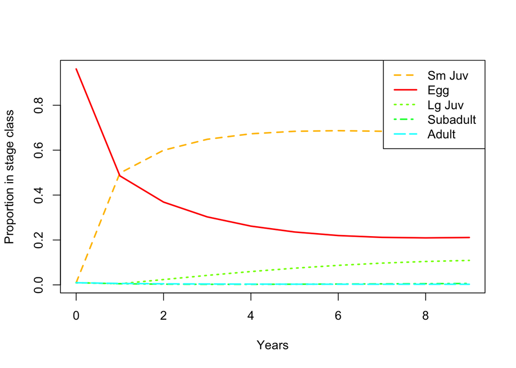

```r
n_0 <- c(1000, 10, 10, 10, 10) # Initial abundance

pop <- pop.projection(A, n_0, iterations = 10) # Project the matrix forward. Package also provides plotting routine

stage.vector.plot(pop$stage.vector) # Plot each stage through time (proportion of each stage). Quickly population comes to be dominated by small juveniles.
```

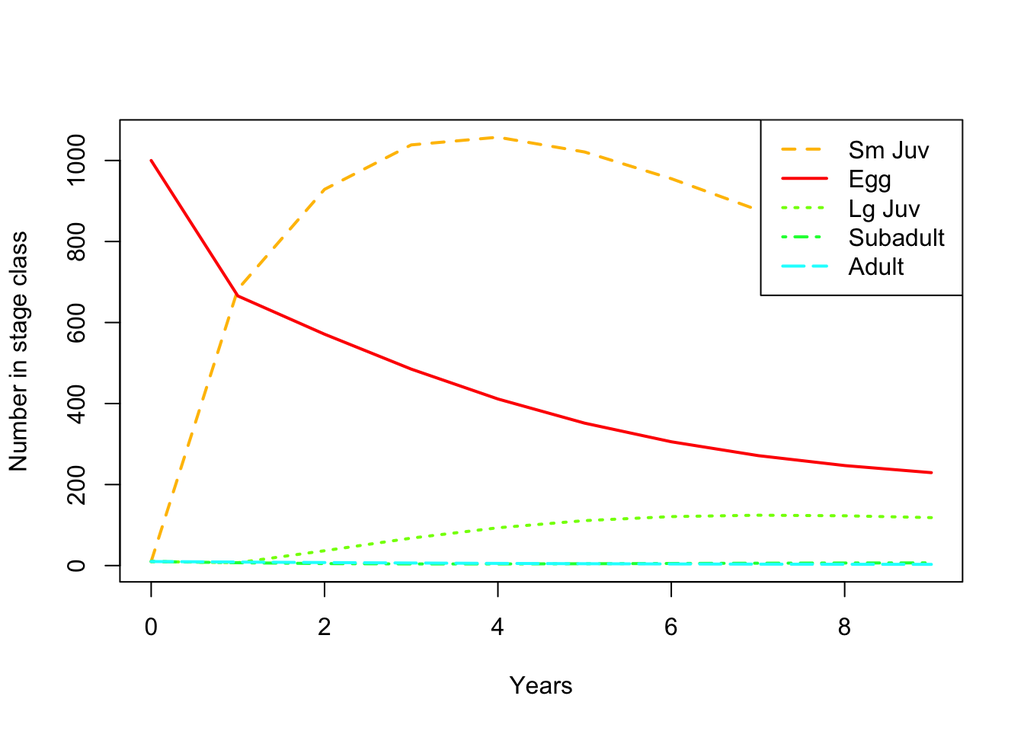

```r
#By default, the above code plots the proportions in each stage through time. To see the actual abundances, use
stage.vector.plot(pop$stage.vector, proportions = FALSE) # We see dcline in egg, big increase in small juveniles.
```

```r
# This is N0 - to get N1 take A %*% n_0 - can do this in console

n_1 <- A %*% n_0

n_2 <- A %*% n_1
```

**2.2. Plot `pop$pop.size` and `pop$pop.changes` through time. What do these plots tell us?**

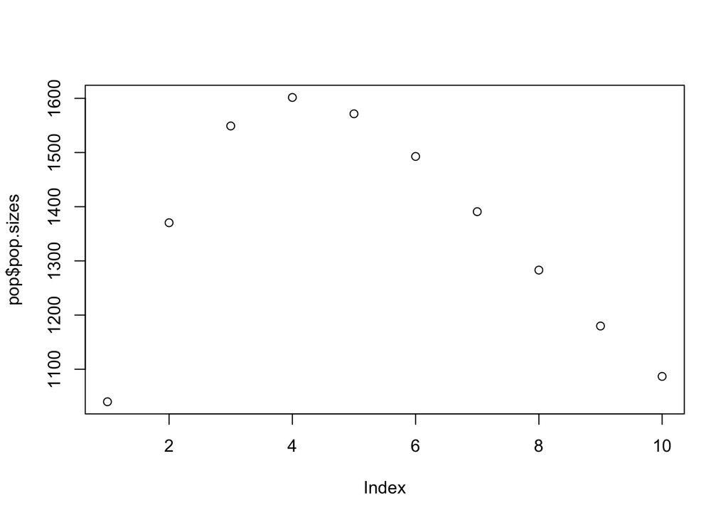

```r
# Total number of individauls across all the stages (pop$pop.sizes)
plot(pop$pop.sizes)
```

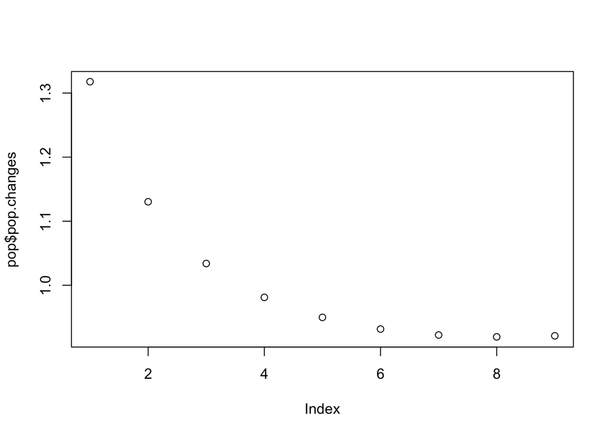

```r
help("pop.projection")

# ALl stages would be increasing or decreasing at same rate if we were at stable stage distriubtion (SSD)

# Proportional change in population size
plot(pop$pop.changes)
```

`pop$pop.size` tells us the total number of individuals across all the stages of the life cycle. When we plot the population for Loggerhead sea turtles, we see that the number of individuals increases over time until the population reaches about 1600 individuals. Then, the population decreases over time until the population reaches about 1100 individuals.

**2.3. Examine the stage vector plot. Has stable stage distribution (SSD) been achieved by the end of your simulated time series?**

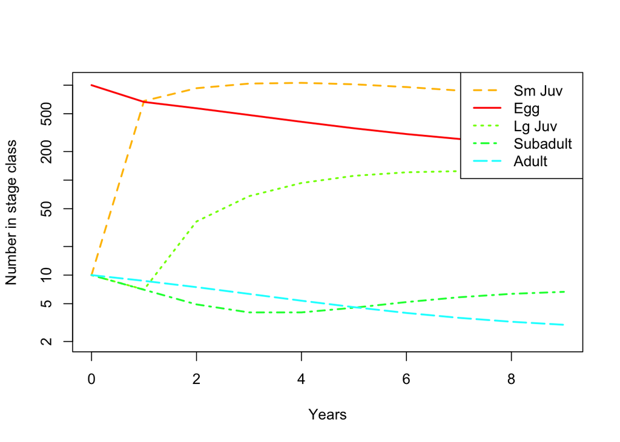

```r
# Once the population has reached the stable stage distribution (SSD), all stages will grow or decline exponentially with the same growth rate. Looking at the stage vector plot, has this been acheived by the end of your simulated time series? (Tip: this might be easier to determine if you make the plot with abundance on a log scale. You can do this by including log = "y" in the call to stage.vector.plot)


# Look at stage classes using log scale using actual abundance and not proportions:
stage.vector.plot(pop$stage.vector, proportions = FALSE, log = "y")

# Log scale versus non-log scale: Changing exponentially - on log scale that is a straight line. This is visually more easy to assess. Hard to eyeball exponential curves. Proportions of each stage will tell you if we've reached SSD but won't tell us the numbers (?)

pop_project <- pop.projection(A, n_0, iterations = 20) # project matrix

stage.vector.plot(pop$stage.vector, proportions = FALSE, log = "y")
```

Stable stage distribution (SSD) has not been achieved in this time series because the sub-adult and adult stages are not declining at the same growth rate.

**2.4. Run simulation for longer time series to see when population appears to be at SSD.**

[figure not shown]

```r
#If the population has not reached the SSD, run the simulation for longer. How many years are required before the population appears to be at the SSD?

# Increase # of iterations from 10 to 20 to see if population reaches the SSD
pop_SSD <- pop.projection(A, n_0, iterations = 50)

# Plot stage classes using log scale using actual abundance and not proportions:
stage.vector.plot(pop_SSD$stage.vector, proportions = FALSE, log = "y")
```

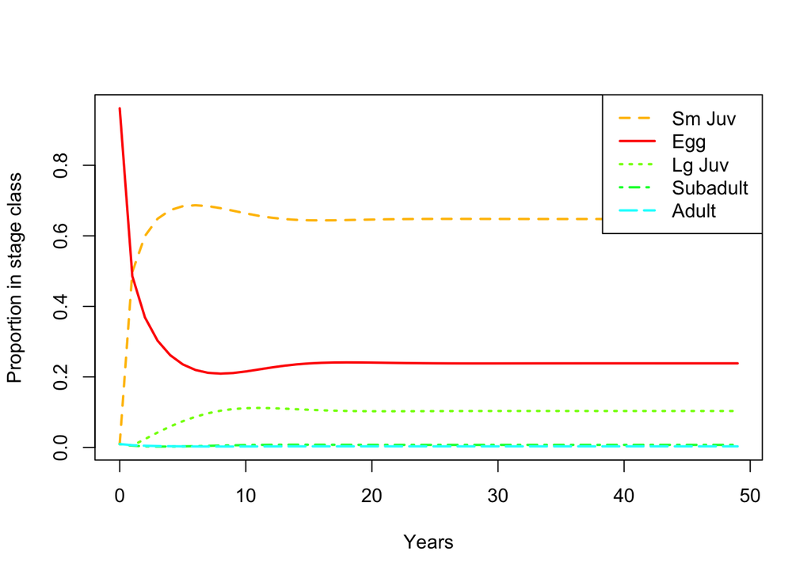

```r
# Plot each stage through time using proportions
stage.vector.plot(pop_SSD$stage.vector)
```

The population has reached SSD when the lines on the plot are parallel. Looking at the plot for proportions of population change, it takes around 15-20 years before population reaches SSD.

### 3. Analyzing the population matrix.

Eigenvalues and eigenvectors give a lot of information about the “asymptotic” (once the population reaches the SSD) dynamics and structure. You can calculate them yourself (see the code in SPsandpiper.R), but the popbio package has two functions to extract the key information:  
`lambda(A)` `stable.stage(A)`

**3.1. Compare the values of `lambda` and SSD with the equivalent outputs of `pop.projection` from the initial run (with only 10 years of simulation). Why are they different?**

```r
lambda(A) #true asymptotic growth rate
```

```
## [1] 0.9515489
```

```r
# 0.951

stable.stage(A) # corresponding eigenvector expressed as proportion
```

```
##         Egg      Sm Juv      Lg Juv    Subadult       Adult
## 0.238508404 0.647732505 0.103356123 0.007285382 0.003117586
```

```r
# Lambda is less than one but we need it to be greater than one for the population to increse.


#        Egg      Sm Juv      Lg Juv    Subadult       Adult
#0.279209989 0.626678506 0.084945390 0.005016370 0.004149745
```

Lambda gives us the stable slope for the entire time series (10 iterations). All stages are stable. SSD gives us the stable slope per stage across the time series.

**3.2. Use the model to evaluate two different management strategies to improve the status of the loggerhead sea turtle population. The two best options are to manage the nesting beaches to increase egg/hatchling survival or to reduce the bycatch of adult turltes in shrimp trawling nets.**

*a. Which element of the projection matrix represents egg/hatchling survival? Which represents adult survival?*

```r
A[2,1] #survival of eggs to small juveniles --> 2nd row, 1st column
```

```
## [1] 0.675
```

```r
# 0.675


A[5,5] #survival of adults (from adults, to adults) --> 5th row, 5th column
```

```
## [1] 0.809
```

```r
# 0.8091
```

*b. Increase egg/hatchling survival in the model, and re-calculate λ1. By how much does it increase? Experiment with different values of this survival term until you get an asymptotic growth rate of 1 or more. How large does egg survival need to be to achieve this?*

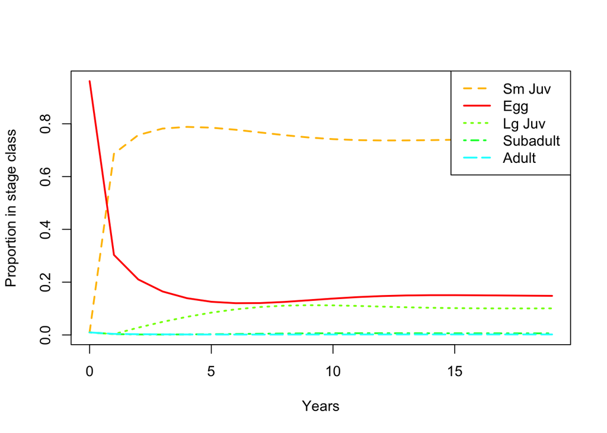

```r
# Change egg/hatching survival rate by increasing A[2,1]
#A[2,1] <- 1.5
# Check if asymptotic growth rate is now >1
#lambda(A)

# Make new matrix for increased survivability of hatchlings
class_names <- c("Egg", "Sm Juv", "Lg Juv", "Subadult", "Adult")
A_juvenile <- matrix(c(0, 0, 0, 4.665, 61.896,
                       1.5, 0.703, 0, 0, 0,
                       0, 0.047, 0.657, 0, 0,
                       0, 0, 0.019, 0.682, 0,
                       0, 0, 0, 0.061, 0.809),
nrow = 5, ncol = 5, byrow = TRUE, dimnames = list(class_names, class_names))

# Plot
n_0 <- c(1000, 10, 10, 10, 10) # Initial abundance

pop_juvenile <- pop.projection(A_juvenile, n_0, iterations = 20) # Project the matrix forward. Package also provides plotting routine

stage.vector.plot(pop_juvenile$stage.vector) # Plot each stage through time (proportion of each stage). Quickly population comes to be dominated by small juveniles.
```

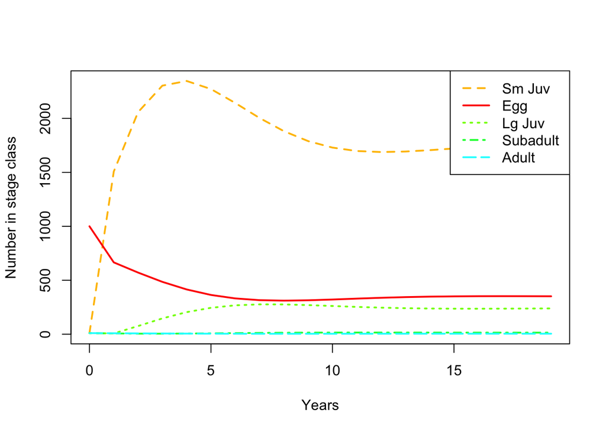

```r
#By default, the above code plots the proportions in each stage through time. To see the actual abundances, use
stage.vector.plot(pop_juvenile$stage.vector, proportions = FALSE)
```

```r
lambda(A_juvenile)
```

```
## [1] 1.000698
```

```r
# Have to increase survivability to 1.5 to get lambda greater than one
# Is this attainable?
# Also need to reduce bycatch to help adults

# Management practices can be more or less affective depending on which life cycle they are targeting
```

In order to increase survivability for hatchlings, we would need to increase survivability to 1.5 to acheive lambda greater than one. This is not attainable.

*c. Put the egg survival back to its original value, increase adult survival in the model, and re-calculate λ1. By how much does it increase? Experiment with different values of this survival term until you get an asymptotic growth rate of 1 or more. How large does adult survival need to be to achieve this?*

```r
# Change egg/hatching survival rate back to its original value. Since I made a new matrix for juveniles, I can simply use A. But want to make sure that all values are correct.
A[2,1] <- 0.675

# Increase adult survival rate
A[5,5] <- 0.95

# Check if asymptotic growth rate is now >1
lambda(A)
```

```
## [1] 1.015079
```

```r
# Lambda = 1.015079


# Increase adult survival rate
A[5,5] <- 0.93

# Check if asymptotic growth rate is now >1
lambda(A)
```

```
## [1] 1.003739
```

```r
# 1.003739

# 0.93 is the lowest we can go to get it >1
```

Lambda must be greater than 1 in order for the population to increase. We need to increase adult survival rate to 0.93 or greater in order to achieve this.

*d. Based on this analysis, which life stage seems the more promising one to target managment at? What else would you need to know to reach a final conclusion?*

We should prioritize increasing adult survivability as this is more attainable than increasing hatchling survivability (increasing 0.93 vs. 1.5). One way we could achieve this is by focusing our management efforts on reducing adult bycatch of sea turtles in order to increase adult survivability. However, we would want to run the same tests on each individual life stage as well.